# 3b_Änderung der Slowdownfunktion

## Modifiziertes SIR Modell mit Änderungen der slowdown-Funktion

(von Anna Hundertmark)

In diesem Skript wird das modifizierzte SIR Modell für den Fall der unvollständig erfassten Infizierten und der Verlangsammung der Infektionsrate Infolge von Kontakt-reduzierenden Maßnahmen angewendet. Das Ziel dieser Modifizierung ist die Anpassung an die von RKI ermittelten tatsächtlichen Zahlen der Corona Infizierten in Deutschland.

Inspiriert von der Studie https://www.medrxiv.org/content/10.1101/2020.03.26.20044214v1.full.pdf

S:susceptible I:Infected R:Recovered \begin{eqnarray} S'(t)&=&-\frac{c(t)}{rN}S(t)I(t)\\ I'(t)&=&\frac{c(t)}{N}S(t)I(T)-wI(t)\\ R'(t)&=&wI(t)- dI(t)\\ \end{eqnarray} hier $N$ ist die Kapazitätsgrenze (Befölkerung die sich insgesammt ansteckt), $c(t)=c_0 slowdown(t)$ ist die zeitabängige Infektionsrate, $c_0$- die Basisinfektionsrate (die des exponenziellen Wachstum zum Anfang der Epidemie), $w=1/14$ ist die tägliche Wechselrate von der Gruppe der Infizierten in die Gruppe der Genesenen (oder Toten), (14 Tage Genesungszeit) und $d=0.003$ ist die Todesrate.

Es gilt hier der Erhaltungsgesetz $S'+\frac{I'}{r}+\frac{R'}{r}=-dI$. Bei $d=0$ (werden Toten in der Gruppe R der Genesenen mitgezählt) folgt $S+\frac{I}{r}+\frac{R}{r}=N$. Bei $r=1$ erhalten wir das original SIR Modell.

#### CoronaDaten - Fallzahlen des RKI

Die Funktion 'coronaData' übergibt die vom RKI ermittelten täglichen Daten zu Corona-Infizierten in Deutschland seit 26. Februar 2020. In der Ersten Zeile der Rückgabe-Matrix werden die kummulierten Infizierten, in der zweiten Zeile werden die Todesfälle und in dritten Zeile werden die Genesenen Infizierten gespeichert

```matlab
% Inhalt aus coronaData.m
% Last Date: 12.5.2020
function y= coronaData ()
	infects = [    16.0     18.0     21.0     26.0     53.0     66.0    117.0    150.0    188.0    240.0    400.0    639.0    795.0    902.0   1139.0   1296.0   1567.0   2369.0   3062.0   3795.0   4838.0   6012.0   7156.0   8198.0  10999.0  13957.0  16662.0  18610.0  22672.0  27436.0  31554.0  36508.0  42288.0  48582.0  52547.0  57298.0  61913.0  67366.0  73522.0  79696.0  85778.0  91714.0  95391.0  99225.0 103228.0 108202.0 113525.0 117658.0 120479.0 123016.0 125098.0 127584.0 130450.0 133830.0 137439.0 139897.0 141672.0 143457.0 145694.0 148046.0 150383.0 152438.0 154175.0 155193.0 156337.0 157641.0 159119.0 160758.0 161703.0 162496.0 163175.0 163860.0 164807.0 166091.0 167300.0 168531.0 169218.0];
	deads = [   0.0    0.0    0.0    0.0    0.0    0.0    0.0    0.0    0.0    0.0    0.0    0.0    0.0    0.0    0.0    0.0    0.0    0.0    0.0    0.0    0.0    0.0    0.0   12.0   20.0   31.0   46.0   55.0   86.0  114.0  149.0  198.0  253.0  325.0  389.0  455.0  583.0  732.0  872.0 1017.0 1158.0 1342.0 1434.0 1607.0 1861.0 2107.0 2373.0 2544.0 2673.0 2799.0 2969.0 3254.0 3569.0 3868.0 4110.0 4294.0 4404.0 4598.0 4879.0 5094.0 5321.0 5500.0 5640.0 5750.0 5913.0 6115.0 6288.0 6481.0 6575.0 6649.0 6692.0 6831.0 6996.0 7119.0 7266.0 7369.0 7395.0];
    recovered = [0.0, 0.0, 0.0, 0.0, 0.0, 0.0, 0.0, 0.0, 0.0, 0.0, 0.0, 0.0, 0.0, 0.0, 0.0, 0.0, 0.0, 0.0, 0.0, 0.0, 0.0, 0.0, 0.0, 0.0, 0.0, 0.0, 0.0, 0.0, 0.0, 0.0, 0.0, 0.0, 0.0, 0.0, 0.0, 13500.0, 16100.0, 18700.0, 21400.0, 23800.0, 26400.0, 28700.0, 30600.0, 33000.0, 46300.0, 49000.0, 53913.0 57400.0 60200.0 64300.0 68200.0 72600.0 77000.0 81800.0 85400.0 88000.0 91500.0 95200.0 99400.0 103300.0 106800.0 109800.0 112000 114500 117400.0 120400.0 123500.0 126900.0 129000.0 130600.0 132700.0 135100.0 137400.0 139900.0 141700.0 143300.0 144400.0];
	y=[infects;deads;recovered];
endfunction
```

#### Implementation grundlegender Parameter

```matlab
%Parameter des modifizierten SIR Models
NM=55000; % Kapazitätsgrenze, 2/3 der deutschen Bevölkerung

c=0.3237; %Basisinfektionsrate- die Rate des exponenziellen Wachstums am Anfang der Pandemie
w=1/14; % Wechselrate zu den Genesenen
d=0.003; % Todesrate
r=0.1;%Anteil der erfassten Infizierten
```

##### Darstellen der aktuellen Daten

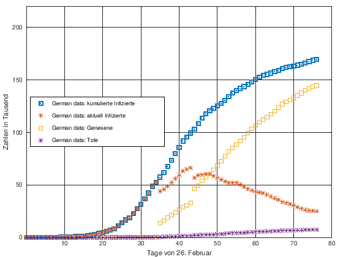

```matlab
%%aktuelle Daten: (passen nicht mehr zur exponenzieller Funktion)
 A=coronaData(); %  A ist eine Matrix
 inf_falleWHO=A(1,:); %nimmt die kumulierten Infizierten (erste Zeile und alle Spalten) der Matrix
  inf_falleWHOrecovered=A(3,:); % nimmt die Genesenen (dritte Zeile und alle Spalten) der Matrix
 inf_falleWHOtoten=A(2,:);%nimmt die Toten (zweite Zeile und alle Spalten) der Matrix

 inf_falleWHOaktuell=inf_falleWHO-inf_falleWHOrecovered;% die aktuell Infizierten ergeben sich aus der Differenz der kumulierten Infiziertn minus der Genesenen für jeden Tag, da die Vektoren durch die Spalten die Tage wiederspiegeln
 n=length(inf_falleWHO);
 timesWHO=[0:1:n-1];

 figure(1)

 title ('Corona- infizierten Detuschland, Quelle RKI')
   plot (timesWHO, inf_falleWHO./1000, 's', "linewidth",4, timesWHO,inf_falleWHOaktuell/1000, '*' , timesWHO,inf_falleWHOrecovered/1000,'s',  timesWHO, inf_falleWHOtoten./1000 , '*' )
   xlabel ('Tage von 26. Februar')
   ylabel ('Zahlen in Tausend')
   legend ( "German data: kumulierte Infizierte" ,"German data: aktuell Infizierte ","German data: Genesene", "German data: Tote" ,"location", "west")
   grid on
   xticks([10,20,30,40,50,60,70,80])

   axis([0,80, 0 ,220])
```

- Die Sprünge innerhalb der Daten lassen sich damit erklären, dass die Meldungen der Infizierten an das RKI auch zeitverzögert erfolgen können -> an Sonntagen arbeiten Labore nicht -> mehr Meldungen am Montag

### Verlangsamte Infektionsrate

Hier kann man die zeitabhängige Infektionsrate Imfolge der Maßnahmen der Kontaktreduzierung implementieren.

Zur Errinerrung (stimmt es?, korrigieren Sie)

1. Kontaktverbot am 22. März (Tag 26)
2. Schulschließung am 15. März (Tag 19)
3. Lockerung der Maßnahmen ab April 27.

##### Implementation verschiedener Infektionsraten

```matlab
function val=slowdown(x,t)
% Ab Tag t (Argument der Funktion) wird die Infektionsrate  in mehreren Schritten sinken:
if x<t val=1 ;
    else  if x<t +10
        val=t./(x.^1.05);
    else if x<t +22
        val=t./(x.^1.2);
    else val=t./(x.^1.27)  ;
endif
endif
endif
%Beispielhafte Lockerung der Maßnahmen ab Tag 80, die die Infektionsrate wieder auf 50 % der Basisinfektionsrate erhöht
%(um den Effekt der Lockerung zu beobachten)
if x> 80  val=0.5;
endif
endfunction
```

```matlab
function val=slowdown2(x,t)
% Ab Tag t (Argument der Funktion) wir die Infektionsrate  in mehreren Schritten sinken:
if x<t val=1 ;
    else  if x<t +10 val=t./(x.^1.13);
    else if x<t +22 val=t./(x.^1.32);
    else val=t./(x.^1.37)  ;
endif
endif
endif
%Beispielhafte Lockerung der Maßnahmen ab Tag 80, die die Infektionsrate wieder auf 50 % der Basisinfektionsrate erhöht
%(um den Effekt der Lockerung zu beobachten)
if x> 80  val=0.5;
endif
endfunction
```

```matlab
function val=slowdown3(x,t)
% Ab Tag t (Argument der Funktion) wir die Infektionsrate  in mehreren Schritten sinken:
if x<t val=1 ; %vor Tag t passiert nichts, x ist kleiner als t
    else  if x<t +10 val=t./(x.^1.13);  % x ist größer als t; x läuft zwischen t und t+10
            else if x<t +22 val=t./(x.^1.32);  % x ist ist größer als t+10 und kleiner als t+20
                    else if x<t +40 val=t./(x.^1.37)  ;
                            else val=0.4;
                           endif
                    endif
            endif
endif
%Beispielhafte Lockerung der Maßnahmen ab Tag 80, die die Infektionsrate wieder auf 50 % der Basisinfektionsrate erhöht
%(um den Effekt der Lockerung zu beobachten)
if x> 80  val=0.5; endif
endfunction
```

#### Vergleich der tatsächtlicher Infektionsrate $c_{Data}$ mit der 'slowdown' Funktion

Im Folgenden wird die Infektionsrate $c_{Data}(t)$ aus den RKI- Daten berechnet: $$c_{Data}(t)=\frac{I_{RKI}(t)-I_{RKI}(t-1)}{ I_{RKI}(t-1)}, $$ wobei $I_{RKI}(t)$ die kummulative Anzahl der Infizerten (RKI-Data) bezeichnet, $t$- Zeit in Tagen.

Die Verlangsammung der Infektionsrate ab Tag $25$-21. März:

```
T =  1
```

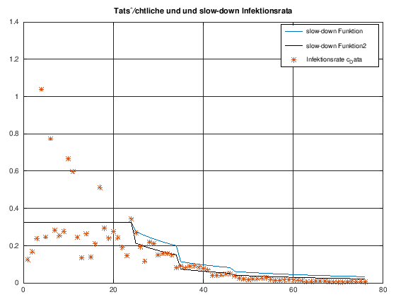

```matlab
%Slowdown-Funktion
for i=1:length(timesWHO)
cc(i)=slowdown (timesWHO (i), 25)*c;
cc2(i)=slowdown2 (timesWHO(i), 25)*c;
endfor
plot  (timesWHO,cc,timesWHO,cc2,'k')
hold on

%infektionsrate aus den RKI-Daten berechnet:
T=1
ccc(1)=cc(1);
for i=T+1:n
ccc(i-T)=(inf_falleWHO(i)-inf_falleWHO(i-T))/(inf_falleWHO(i-T) );
endfor

plot (ccc, '*')
grid on
title ('Tatsächtliche und und slow-down Infektionsrata')
legend ('slow-down Funktion','slow-down Funktion2', 'Infektionsrate c_Data' )
hold off
```

### Numerische Lösung des SIR -Systems

Die Octave Funktion 'lsode' löst ein System gewöhnlicher Differentialgleichungen mit adequaten numerischen Methoden.

'lsode' übernimmt als Parameter den Namen der Funktion $f$ der rechten Seite des System der gewönlicher Differentialgleichungen:
$$\vec{y}'=f(\vec{y},t), \quad t\in [t_0,T], \ \vec{y}(t)=(y_1(t),y_2(t),y_3(t))^T,$$ den Anfangsvektor yo:=$y(t_0)=(y_1(t),y_2(t),y_3(t))^T$ und den Vektor der Zeitschritte 'times':=$(t_1,..,t_n=T)$ in dem die Lösung berechnet werden sollte.

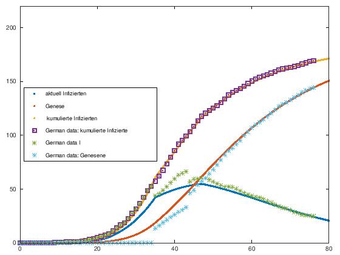

```matlab
%Lösung des ODE Systems (ordinary differential equations)

 times=(0:0.1:180);

  %Anfangsbedingungen
    yo=[NM-16/1000;16/1000;0];

    f=@(y,x) [-c*slowdown(x,25)*y(1)*y(2)/(r*NM);c*slowdown(x,25)*y(1)*y(2)/NM-w*y(2);w*y(2)-0*y(2)]; % modifiziertes SIR-Modell
    y = lsode (f, yo, times);

  figure(2)
   plot ( times, y (:,2), '.', times, y (:,3),'.',times, y (:,3)+y (:,2),'.')
   hold on

   plot (timesWHO, inf_falleWHO./1000, 's', "linewidth",4, timesWHO,inf_falleWHOaktuell/1000, '*' , timesWHO,inf_falleWHOrecovered/1000, '*' )
   legend ( "aktuell Infizierten", "Genese", " kumulierte Infizierten","German data: kumulierte Infizierte" ,"German data I ","German data: Genesene" ,"location", "west")

   axis([0,80, 0 ,220])
```

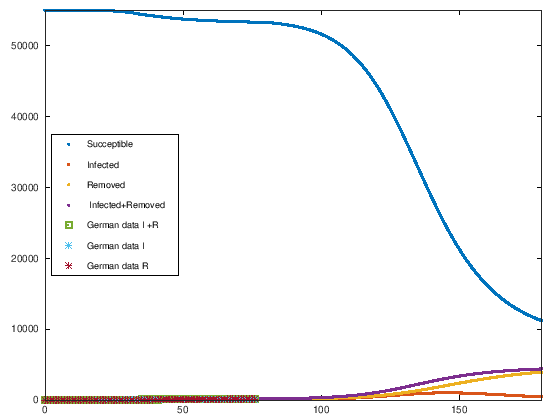

```matlab
figure(3)
   plot ( times, y (:,1), '.', times, y (:,2), '.', times, y (:,3),'.',times, y (:,3)+y (:,2),'.')
   hold on

   plot (timesWHO, inf_falleWHO./1000, 's', "linewidth",4, timesWHO,inf_falleWHOaktuell/1000, '*' , timesWHO,inf_falleWHOrecovered/1000, '*' )
   legend ( "Succeptible","Infected", "Removed", " Infected+Removed","German data I +R" ,"German data I ","German data R" ,"location", "west")
   axis([0,180, 0 ,55020])
```

In folgender Zelle wird der relativer Fehler der numerischen Lösung des SIR Models (Gruppen I, R) zu den RKI Daten berechnet. Es werden verschieden Maßen des Fehlers berechnet.

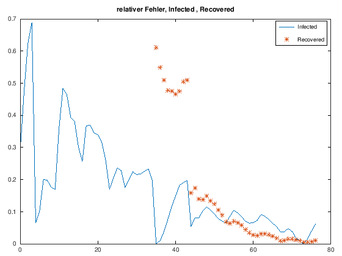

```matlab
%relat. Fehler Infizierte

%Interpolation der Funktionswerte an die RKI-Zeiten (Tage) % hier wird der Fehler zwischen den Daten und der numerischen Lösung berechnet (da Skala der WHO nicht mit numerieschen Lösungsskala übereinstimmt) -> numerische Lösung muss an reale Daten anpassen
I=interp1 (times, y(:,2), timesWHO+1);
abs_I=abs(I-inf_falleWHOaktuell/1000);
rel_I=abs(I-inf_falleWHOaktuell/1000)./(inf_falleWHOaktuell/1000);

plot (timesWHO, rel_I)
title ('relativer Fehler, Infected , Recovered')
hold on
%Fehlermaß
maas_I=norm(abs_I)/norm(inf_falleWHOaktuell/1000);
%weiterer  Fehlermaß Durchschnitt und Euklid-Norm
rel_I_mean=mean(rel_I); %mittlere relative Fehler
rel_I_norm=norm(rel_I); %Norm des relativen Fehlers

%relat. Fehler Genesene/Toten
R=interp1 (times, y(:,3), timesWHO+1);
abs_R=abs(R-inf_falleWHOrecovered/1000);
rel_R=abs(R-inf_falleWHOrecovered/1000)./(inf_falleWHOrecovered/1000);

plot (timesWHO, rel_R, '*')
hold off
legend('Infected', 'Recovered')
%Fehlermaß
maas_R=norm(abs_R)/norm(inf_falleWHOrecovered/1000);
% weiterer Fehlermaß: Durchschnitt und Euklid-Norm
rel_R_mean=mean(rel_R(36:length(timesWHO)));
rel_R_norm=norm(rel_R(36:length(timesWHO)));
```

### Aufgaben zur selbständiger Arbeit

1. Wählen Sie eine geeignete Basis-Infektionsrate c, die das exponenzielle Wachstum (ca bis Ende April 2020) 'gut' abbildet. Vergleichen Sie dazu die Funktion des exponenziellen Wachstums $I(t)=I_0e^{k*(t-t_0)}$, hier $k=c/N$ aus SIR-Modell, mit den Daten des RKI zu den Infizierten in Deutschland

Hinweis: verwenden Sie 'Augenmaß' oder besser die Regression, d.h. finden Sie die Infektionsrate k, die das Residuum $\sum_{i=1}^n (I^i_{RKI}-I(t_i))^2$ minimiert.

1. Schlagen Sie eine andere 'slowdown2' Funktion zur Verlangsammung der Infektionsrate im Einklang mit den der Kontaktverbot- und Lockerungsmaßnahmen und nutzen Sie diese im SIR Modell (Infektionsrate 'c*slowdown2'). Experimentieren Sie und versuchen Sie das obere Ergebniss des SIR Modells mit 'slowdown2' zu verbessern (betrachten Sie dazu den relat. Fehler)
2. Untersuchen Sie anhand Ihres SIR Modells, welchen Einfluß ein Anstieg der Infektionsrate (nachdem diese durch die Maßnahmen reduziert wurde) im Folge der Lockerung der Kontaktverbotmaßnahmen an die Infizerten-Zahlen hat.
3. Mithilfe des SIR Modells ohne Verlangsammung der Infektionsrate (ohne slowdown) stellen Sie ein Szenario der Pandemie in Deutschland dar, welches potenziell ohne die Kontaktreduzierende Maßnahmen auftreten konnte.
4. Welchen Einfluß hat Parameter r in dieser Modellierung? (Untersuchen Sie die Fälle $r<1$ und $r=1$)

## Hinweis für Frau Hundertmark

Aufabe 1 und 2 wurden in dieser Datei bearbeitet. (c in In2; slowdown in In5 und In6); Aufgabe 3, 4 und 5 wurden in der Datei SIR_Modell-Gauer-Lemke-Pfaffmann bearbeitet

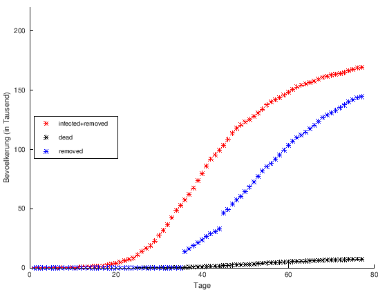

```matlab
%Corona-Daten geplottet
figure(99)
data = coronaData();
hold on
plot(data(1,:)./1000,'*r',data(2,:)./1000,'*k',data(3,:)./1000,'*b')
 legend ("infected+removed","dead","removed","location", "west")
 xlabel ('Tage')
 ylabel ('Bevoelkerung (in Tausend)')
 axis([0,80, 0 ,220])
```